# Compréhension et visualisation des données

## Exercise 1 : Compréhension et visualisation des données

## Realise par : Donovan Daniel Del Valle Jimenez

```python
import sklearn
import numpy as np
import scipy as sp
import pandas as pd
import matplotlib.pyplot as plt
import seaborn as sns
from sklearn.decomposition import PCA
from sklearn.preprocessing import StandardScaler
from mpl_toolkits.mplot3d import Axes3D
from sklearn.metrics.pairwise import euclidean_distances
from sklearn.metrics.pairwise import manhattan_distances
%matplotlib notebook
from sklearn.mixture import GaussianMixture
import matplotlib as mpl
```

Données : Iris est un ensemble de données très connu du domaine de la science des données. Il contient 150 observations (ou objets) réparties en 3 classes (appelées respectivement setosa, versicolor, virginica) de 50 observations chacune. Chaque objet d’Iris est décrit par 4 variables (sepal_length, sepal_width, petal_length, petal_width).

```python
data_file = 'iris.csv'
data = pd.read_csv(data_file)
```

```python
data.shape
```

```
(150, 5)
```

```python
data.head()
```

|  | sepal_length | sepal_width | petal_length | petal_width | species |
| --- | --- | --- | --- | --- | --- |
| 0 | 5.1 | 3.5 | 1.4 | 0.2 | setosa |
| 1 | 4.9 | 3.0 | 1.4 | 0.2 | setosa |
| 2 | 4.7 | 3.2 | 1.3 | 0.2 | setosa |
| 3 | 4.6 | 3.1 | 1.5 | 0.2 | setosa |
| 4 | 5.0 | 3.6 | 1.4 | 0.2 | setosa |

```python
data.corr()
```

|  | sepal_length | sepal_width | petal_length | petal_width |
| --- | --- | --- | --- | --- |
| sepal_length | 1.000000 | -0.117570 | 0.871754 | 0.817941 |
| sepal_width | -0.117570 | 1.000000 | -0.428440 | -0.366126 |
| petal_length | 0.871754 | -0.428440 | 1.000000 | 0.962865 |
| petal_width | 0.817941 | -0.366126 | 0.962865 | 1.000000 |

Méthode 1 (pas de visualisation) : La méthode 1 vise à présenter la séparation entre les classes par des fonctions de séparation.

```python
attributs = ['sepal_length', 'sepal_width' ,'petal_length', 'petal_width']
X = data.loc[:, attributs]
y = data.loc[:,['species']].values
```

```python
class0=data.loc[data['species']=='setosa']
class0 = class0.loc[:, attributs]
mean0=class0[['sepal_length', 'sepal_width' ,'petal_length', 'petal_width']].mean()

class1=data.loc[data['species']=='versicolor']
class1 = class1.loc[:, attributs]
mean1=class1[['sepal_length', 'sepal_width' ,'petal_length', 'petal_width']].mean()

class2=data.loc[data['species']=='virginica']
class2 = class2.loc[:, attributs]
mean2=class2[['sepal_length', 'sepal_width' ,'petal_length', 'petal_width']].mean()

m0_center=mean0.values.reshape(1,-1)
m1_center=mean1.values.reshape(1,-1)
m2_center=mean2.values.reshape(1,-1)
```

```python
class0.head()
```

|  | sepal_length | sepal_width | petal_length | petal_width |
| --- | --- | --- | --- | --- |
| 0 | 5.1 | 3.5 | 1.4 | 0.2 |
| 1 | 4.9 | 3.0 | 1.4 | 0.2 |
| 2 | 4.7 | 3.2 | 1.3 | 0.2 |
| 3 | 4.6 | 3.1 | 1.5 | 0.2 |
| 4 | 5.0 | 3.6 | 1.4 | 0.2 |

```python
class1.head()
```

|  | sepal_length | sepal_width | petal_length | petal_width |
| --- | --- | --- | --- | --- |
| 50 | 7.0 | 3.2 | 4.7 | 1.4 |
| 51 | 6.4 | 3.2 | 4.5 | 1.5 |
| 52 | 6.9 | 3.1 | 4.9 | 1.5 |
| 53 | 5.5 | 2.3 | 4.0 | 1.3 |
| 54 | 6.5 | 2.8 | 4.6 | 1.5 |

```python
class2.head()
```

|  | sepal_length | sepal_width | petal_length | petal_width |
| --- | --- | --- | --- | --- |
| 100 | 6.3 | 3.3 | 6.0 | 2.5 |
| 101 | 5.8 | 2.7 | 5.1 | 1.9 |
| 102 | 7.1 | 3.0 | 5.9 | 2.1 |
| 103 | 6.3 | 2.9 | 5.6 | 1.8 |
| 104 | 6.5 | 3.0 | 5.8 | 2.2 |

```python
print("Le centre de la classe setosa est: ")
print(mean0)
print("Le centre de la classe versicolor est:")
print(mean1)
print("Le centre de la classe virginica est:")
print(mean2)
```

```
Le centre de la classe setosa est:
sepal_length    5.006
sepal_width     3.428
petal_length    1.462
petal_width     0.246
dtype: float64
Le centre de la classe versicolor est:
sepal_length    5.936
sepal_width     2.770
petal_length    4.260
petal_width     1.326
dtype: float64
Le centre de la classe virginica est:
sepal_length    6.588
sepal_width     2.974
petal_length    5.552
petal_width     2.026
dtype: float64
```

```python
dist_setosa=euclidean_distances(class0,m0_center)
dist_versicolor=euclidean_distances(class1,m1_center)
dist_virginica=euclidean_distances(class2,m2_center)

#print(dist_setosa)
dist_setosa_max=np.amax(dist_setosa)
dist_versicolor_max=np.amax(dist_versicolor)
dist_virginica_max=np.amax(dist_virginica)
print("distance intraclasse maximale en setosa: ", dist_setosa_max)
print("distance intraclasse maximale en versicolor: ", dist_versicolor_max)
print("distance intraclasse maximale en virginica: ", dist_virginica_max)
```

```
distance intraclasse maximale en setosa:  1.2480304483465172
distance intraclasse maximale en versicolor:  1.5525694831472112
distance intraclasse maximale en virginica:  2.0705071842425484
```

```python
# (p-q)
x_minus_mu = class0 - m1_center
# matrice de covariance
cov = np.cov(class0.T)
# T de la matrice de covariance
inv_covmat = np.linalg.inv(cov)
# (p-q * T de  la matrice de covariance)
right = np.dot(x_minus_mu, inv_covmat)
# Dot product of two arrays: (p-q)T * right
mahal = np.dot(right, x_minus_mu.T)
dist_mh_0_1 = mahal.diagonal()

x_minus_mu = class0 - m2_center
cov = np.cov(class0.T)
inv_covmat = np.linalg.inv(cov)
right = np.dot(x_minus_mu, inv_covmat)
mahal = np.dot(right, x_minus_mu.T)
dist_mh_0_2 = mahal.diagonal()

dist_setosa_versicolor_min=np.amin(dist_mh_0_1)
dist_setosa_virginica_min=np.amin(dist_mh_0_2)
print("distance interclasse minimale entre le Center Versicolor et Setosa : ", dist_setosa_versicolor_min)
print("distance interclasse minimale entre le Center Virginica et Setosa: ", dist_setosa_virginica_min)
```

```
distance interclasse minimale entre le Center Versicolor et Setosa :  252.2015503707919
distance interclasse minimale entre le Center Virginica et Setosa:  593.1120192019928
```

```python
class0.loc[:,'Euclidienne Setosa'] = dist_setosa
class0.loc[:,'Mh Setosa - Center Versicolor'] = dist_mh_0_1
class0.loc[:,'Mh Setosa - Center Virginica'] = dist_mh_0_2
class0.head(50)
```

|  | sepal_length | sepal_width | petal_length | petal_width | Euclidienne Setosa | Mh Setosa - Center Versicolor | Mh Setosa - Center Virginica |
| --- | --- | --- | --- | --- | --- | --- | --- |
| 0 | 5.1 | 3.5 | 1.4 | 0.2 | 0.141351 | 341.098349 | 733.400574 |
| 1 | 4.9 | 3.0 | 1.4 | 0.2 | 0.447638 | 324.996791 | 712.615298 |
| 2 | 4.7 | 3.2 | 1.3 | 0.2 | 0.417109 | 352.632175 | 749.462810 |
| 3 | 4.6 | 3.1 | 1.5 | 0.2 | 0.525338 | 316.787057 | 698.825764 |
| 4 | 5.0 | 3.6 | 1.4 | 0.2 | 0.188627 | 347.206022 | 740.630626 |
| 5 | 5.4 | 3.9 | 1.7 | 0.4 | 0.677038 | 281.258481 | 637.213213 |
| 6 | 4.6 | 3.4 | 1.4 | 0.3 | 0.415187 | 335.656294 | 718.128359 |
| 7 | 5.0 | 3.4 | 1.5 | 0.2 | 0.066182 | 321.567624 | 706.045293 |
| 8 | 4.4 | 2.9 | 1.4 | 0.2 | 0.807453 | 329.753045 | 717.044752 |
| 9 | 4.9 | 3.1 | 1.5 | 0.1 | 0.376271 | 325.720958 | 716.865236 |
| 10 | 5.4 | 3.7 | 1.5 | 0.2 | 0.482473 | 329.258473 | 716.175103 |
| 11 | 4.8 | 3.4 | 1.6 | 0.2 | 0.253732 | 309.609116 | 687.384606 |
| 12 | 4.8 | 3.0 | 1.4 | 0.1 | 0.500779 | 339.727035 | 736.981498 |
| 13 | 4.3 | 3.0 | 1.1 | 0.1 | 0.913225 | 402.375709 | 821.195268 |
| 14 | 5.8 | 4.0 | 1.2 | 0.2 | 1.014091 | 394.258752 | 804.516457 |
| 15 | 5.7 | 4.4 | 1.5 | 0.4 | 1.204815 | 335.011059 | 709.451656 |
| 16 | 5.4 | 3.9 | 1.3 | 0.4 | 0.654202 | 350.655961 | 734.480179 |
| 17 | 5.1 | 3.5 | 1.4 | 0.3 | 0.144153 | 329.027480 | 711.826346 |
| 18 | 5.7 | 3.8 | 1.7 | 0.3 | 0.824366 | 285.982525 | 650.053046 |
| 19 | 5.1 | 3.8 | 1.5 | 0.3 | 0.389333 | 325.729016 | 704.529858 |
| 20 | 5.4 | 3.4 | 1.7 | 0.2 | 0.463444 | 286.465382 | 656.477922 |
| 21 | 5.1 | 3.7 | 1.5 | 0.4 | 0.328603 | 310.391843 | 678.699543 |
| 22 | 4.6 | 3.6 | 1.0 | 0.2 | 0.640297 | 431.280506 | 853.104981 |
| 23 | 5.1 | 3.3 | 1.7 | 0.5 | 0.382596 | 252.201550 | 593.112019 |
| 24 | 4.8 | 3.4 | 1.9 | 0.2 | 0.487011 | 266.816391 | 623.689767 |
| 25 | 5.0 | 3.0 | 1.6 | 0.2 | 0.452084 | 291.396332 | 664.947500 |
| 26 | 5.0 | 3.4 | 1.6 | 0.4 | 0.208758 | 282.391913 | 640.895491 |
| 27 | 5.2 | 3.5 | 1.5 | 0.2 | 0.215360 | 323.030429 | 708.232687 |
| 28 | 5.2 | 3.4 | 1.4 | 0.2 | 0.210666 | 336.177148 | 727.356995 |
| 29 | 4.7 | 3.2 | 1.6 | 0.2 | 0.408387 | 302.996416 | 678.924938 |
| 30 | 4.8 | 3.1 | 1.6 | 0.2 | 0.413739 | 297.021425 | 671.827568 |
| 31 | 5.4 | 3.4 | 1.5 | 0.4 | 0.425652 | 295.173295 | 660.113859 |
| 32 | 5.2 | 4.1 | 1.5 | 0.1 | 0.715528 | 367.293224 | 767.937534 |
| 33 | 5.5 | 4.2 | 1.4 | 0.2 | 0.919772 | 368.797018 | 767.497334 |
| 34 | 4.9 | 3.1 | 1.5 | 0.2 | 0.349829 | 311.529844 | 693.170762 |
| 35 | 5.0 | 3.2 | 1.2 | 0.2 | 0.350400 | 366.673617 | 770.073835 |
| 36 | 5.5 | 3.5 | 1.3 | 0.2 | 0.526859 | 356.788462 | 755.527674 |
| 37 | 4.9 | 3.6 | 1.4 | 0.1 | 0.256866 | 363.393991 | 766.454551 |
| 38 | 4.4 | 3.0 | 1.3 | 0.2 | 0.760776 | 351.057861 | 746.306721 |
| 39 | 5.1 | 3.4 | 1.5 | 0.2 | 0.114804 | 320.207537 | 704.552609 |
| 40 | 5.0 | 3.5 | 1.3 | 0.3 | 0.185418 | 348.524008 | 738.422842 |
| 41 | 4.5 | 2.3 | 1.3 | 0.3 | 1.248030 | 316.927506 | 695.611935 |
| 42 | 4.4 | 3.2 | 1.3 | 0.2 | 0.669014 | 360.366865 | 757.595290 |
| 43 | 5.0 | 3.5 | 1.6 | 0.6 | 0.386756 | 271.849371 | 612.336012 |
| 44 | 5.1 | 3.8 | 1.9 | 0.4 | 0.602312 | 253.091995 | 594.519991 |
| 45 | 4.8 | 3.0 | 1.4 | 0.3 | 0.482058 | 314.458334 | 692.706079 |
| 46 | 5.1 | 3.8 | 1.6 | 0.2 | 0.410341 | 322.288416 | 703.625245 |
| 47 | 4.6 | 3.2 | 1.4 | 0.2 | 0.471996 | 337.600763 | 727.596624 |
| 48 | 5.3 | 3.7 | 1.5 | 0.2 | 0.404944 | 330.226244 | 717.275470 |
| 49 | 5.0 | 3.3 | 1.4 | 0.2 | 0.149599 | 334.371775 | 724.827032 |

```python
# (p-q)
x_minus_mu = class1 - m0_center
# matrice de covariance
cov = np.cov(class1.T)
# T de la matrice de covariance
inv_covmat = np.linalg.inv(cov)
# (p-q * T de  la matrice de covariance)
right = np.dot(x_minus_mu, inv_covmat)
# Dot product of two arrays: (p-q)T * right
mahal = np.dot(right, x_minus_mu.T)
dist_mh_1_0 = mahal.diagonal()

x_minus_mu = class1 - m2_center
cov = np.cov(class1.T)
inv_covmat = np.linalg.inv(cov)
right = np.dot(x_minus_mu, inv_covmat)
mahal = np.dot(right, x_minus_mu.T)
dist_mh_1_2 = mahal.diagonal()

dist_versicolor_setosa_min=np.amin(dist_mh_1_0)
dist_versicolor_virginica_min=np.amin(dist_mh_1_2)
print("distance interclasse minimale entre le Center Setosa et Versicolor : ", dist_versicolor_setosa_min)
print("distance interclasse minimale entre le Center Virginica et Versicolor: ", dist_versicolor_virginica_min)
```

```
distance interclasse minimale entre le Center Setosa et Versicolor :  70.90316005598393
distance interclasse minimale entre le Center Virginica et Versicolor:  6.588065562859132
```

```python
class1.loc[:,'Euclidienne Versicolor'] = dist_versicolor
class1.loc[:,'Mh Versicolor - Center Setosa'] = dist_mh_1_0
class1.loc[:,'Mh Versicolor - Center Virginica'] = dist_mh_1_2
class1.head(50)
```

|  | sepal_length | sepal_width | petal_length | petal_width | Euclidienne Versicolor | Mh Versicolor - Center Setosa | Mh Versicolor - Center Virginica |
| --- | --- | --- | --- | --- | --- | --- | --- |
| 50 | 7.0 | 3.2 | 4.7 | 1.4 | 1.231289 | 90.029903 | 29.193511 |
| 51 | 6.4 | 3.2 | 4.5 | 1.5 | 0.698621 | 94.219932 | 19.386479 |
| 52 | 6.9 | 3.1 | 4.9 | 1.5 | 1.215760 | 109.282124 | 18.657532 |
| 53 | 5.5 | 2.3 | 4.0 | 1.3 | 0.692295 | 131.147441 | 14.202917 |
| 54 | 6.5 | 2.8 | 4.6 | 1.5 | 0.681815 | 121.678874 | 11.953270 |
| 55 | 5.7 | 2.8 | 4.5 | 1.3 | 0.338928 | 113.504760 | 21.757098 |
| 56 | 6.3 | 3.3 | 4.7 | 1.6 | 0.825877 | 104.118572 | 15.810918 |
| 57 | 4.9 | 2.4 | 3.3 | 1.0 | 1.496019 | 86.510024 | 33.500554 |
| 58 | 6.6 | 2.9 | 4.6 | 1.3 | 0.757675 | 99.578146 | 25.103031 |
| 59 | 5.2 | 2.7 | 3.9 | 1.4 | 0.825634 | 114.109992 | 16.377180 |
| 60 | 5.0 | 2.0 | 3.5 | 1.0 | 1.467267 | 118.984934 | 27.396702 |
| 61 | 5.9 | 3.0 | 4.2 | 1.5 | 0.296769 | 102.865484 | 15.665557 |
| 62 | 6.0 | 2.2 | 4.0 | 1.0 | 0.709135 | 111.162991 | 31.680318 |
| 63 | 6.1 | 2.9 | 4.7 | 1.4 | 0.492820 | 115.273562 | 17.164011 |
| 64 | 5.6 | 2.9 | 3.6 | 1.3 | 0.752378 | 80.258587 | 28.424975 |
| 65 | 6.7 | 3.1 | 4.4 | 1.4 | 0.847155 | 87.929524 | 25.728583 |
| 66 | 5.6 | 3.0 | 4.5 | 1.5 | 0.503659 | 117.431851 | 14.904700 |
| 67 | 5.8 | 2.7 | 4.1 | 1.0 | 0.394046 | 85.770822 | 40.541612 |
| 68 | 6.2 | 2.2 | 4.5 | 1.5 | 0.694602 | 169.695383 | 10.447005 |
| 69 | 5.6 | 2.5 | 3.9 | 1.1 | 0.605369 | 96.400594 | 26.550171 |
| 70 | 5.9 | 3.2 | 4.8 | 1.8 | 0.838136 | 139.005563 | 7.493421 |
| 71 | 6.1 | 2.8 | 4.0 | 1.3 | 0.309955 | 90.562909 | 22.938158 |
| 72 | 6.3 | 2.5 | 4.9 | 1.5 | 0.803288 | 156.703277 | 8.601911 |
| 73 | 6.1 | 2.8 | 4.7 | 1.2 | 0.487106 | 111.870972 | 31.275447 |
| 74 | 6.4 | 2.9 | 4.3 | 1.3 | 0.484223 | 90.657029 | 24.396827 |
| 75 | 6.6 | 3.0 | 4.4 | 1.4 | 0.720328 | 94.060961 | 22.280558 |
| 76 | 6.8 | 2.8 | 4.8 | 1.4 | 1.021994 | 118.666774 | 18.670845 |
| 77 | 6.7 | 3.0 | 5.0 | 1.7 | 1.150683 | 137.572222 | 6.588066 |
| 78 | 6.0 | 2.9 | 4.5 | 1.5 | 0.329958 | 116.438559 | 11.444256 |
| 79 | 5.7 | 2.6 | 3.5 | 1.0 | 0.876625 | 70.903160 | 38.214163 |
| 80 | 5.5 | 2.4 | 3.8 | 1.1 | 0.767901 | 100.735394 | 24.992122 |
| 81 | 5.5 | 2.4 | 3.7 | 1.0 | 0.864218 | 90.947221 | 31.726074 |
| 82 | 5.8 | 2.7 | 3.9 | 1.2 | 0.410940 | 88.404191 | 24.877179 |
| 83 | 6.0 | 2.7 | 5.1 | 1.6 | 0.888635 | 163.971294 | 7.707803 |
| 84 | 5.4 | 3.0 | 4.5 | 1.5 | 0.654272 | 122.176414 | 16.804338 |
| 85 | 6.0 | 3.4 | 4.5 | 1.6 | 0.730529 | 97.083528 | 20.038712 |
| 86 | 6.7 | 3.1 | 4.7 | 1.5 | 0.957325 | 103.809579 | 17.713287 |
| 87 | 6.3 | 2.3 | 4.4 | 1.3 | 0.611287 | 137.027883 | 16.716607 |
| 88 | 5.6 | 3.0 | 4.1 | 1.3 | 0.438260 | 87.602485 | 25.492810 |
| 89 | 5.5 | 2.5 | 4.0 | 1.3 | 0.575562 | 116.251152 | 15.620628 |
| 90 | 5.5 | 2.6 | 4.4 | 1.2 | 0.504452 | 119.692026 | 25.307565 |
| 91 | 6.1 | 3.0 | 4.6 | 1.4 | 0.448187 | 105.119101 | 18.853162 |
| 92 | 5.8 | 2.6 | 4.0 | 1.2 | 0.361762 | 97.733671 | 22.363047 |
| 93 | 5.0 | 2.3 | 3.3 | 1.0 | 1.457694 | 91.364801 | 31.620793 |
| 94 | 5.6 | 2.7 | 4.2 | 1.3 | 0.349388 | 108.353161 | 18.085874 |
| 95 | 5.7 | 3.0 | 4.2 | 1.2 | 0.357871 | 84.205232 | 32.666921 |
| 96 | 5.7 | 2.9 | 4.2 | 1.3 | 0.277258 | 94.878908 | 22.348084 |
| 97 | 6.2 | 2.9 | 4.3 | 1.3 | 0.298114 | 92.039482 | 22.934356 |
| 98 | 5.1 | 2.5 | 3.0 | 1.1 | 1.552569 | 80.789310 | 37.006089 |
| 99 | 5.7 | 2.8 | 4.1 | 1.3 | 0.287875 | 97.111195 | 20.109983 |

```python
# (p-q)
x_minus_mu = class2 - m0_center
# matrice de covariance
cov = np.cov(class2.T)
# T de la matrice de covariance
inv_covmat = np.linalg.inv(cov)
# (p-q * T de  la matrice de covariance)
right = np.dot(x_minus_mu, inv_covmat)
# Dot product of two arrays: (p-q)T * right
mahal = np.dot(right, x_minus_mu.T)
dist_mh_2_0 = mahal.diagonal()

x_minus_mu = class2 - m1_center
cov = np.cov(class2.T)
inv_covmat = np.linalg.inv(cov)
right = np.dot(x_minus_mu, inv_covmat)
mahal = np.dot(right, x_minus_mu.T)
dist_mh_2_1 = mahal.diagonal()

dist_virginica_setosa_min=np.amin(dist_mh_2_0)
dist_virginica_versicolor_min=np.amin(dist_mh_2_1)
print("distance interclasse minimale entre le Center Setosa et Virginica : ", dist_virginica_setosa_min)
print("distance interclasse minimale entre le Center Versicolor et Virginica: ", dist_virginica_versicolor_min)
```

```
distance interclasse minimale entre le Center Setosa et Virginica :  129.846934553898
distance interclasse minimale entre le Center Versicolor et Virginica:  4.635611082652266
```

```python
class2.loc[:,'Euclidienne Virginica'] = dist_virginica
class2.loc[:,'Mh Virginica - Center Setosa'] = dist_mh_2_0
class2.loc[:,'Mh Virginica -  Center Versicolor'] = dist_mh_2_1
class2.head(50)
```

|  | sepal_length | sepal_width | petal_length | petal_width | Euclidienne Virginica | Mh Virginica - Center Setosa | Mh Virginica - Center Versicolor |
| --- | --- | --- | --- | --- | --- | --- | --- |
| 100 | 6.3 | 3.3 | 6.0 | 2.5 | 0.783964 | 231.171610 | 40.310551 |
| 101 | 5.8 | 2.7 | 5.1 | 1.9 | 0.957183 | 176.270194 | 15.788978 |
| 102 | 7.1 | 3.0 | 5.9 | 2.1 | 0.624019 | 176.207963 | 16.546742 |
| 103 | 6.3 | 2.9 | 5.6 | 1.8 | 0.376563 | 175.442034 | 16.313875 |
| 104 | 6.5 | 3.0 | 5.8 | 2.2 | 0.316544 | 199.292631 | 23.888114 |
| 105 | 7.6 | 3.0 | 6.6 | 2.1 | 1.458972 | 207.027007 | 27.058610 |
| 106 | 4.9 | 2.5 | 4.5 | 1.7 | 2.070507 | 174.637224 | 18.606909 |
| 107 | 7.3 | 2.9 | 6.3 | 1.8 | 1.059717 | 185.178405 | 19.594197 |
| 108 | 6.7 | 2.5 | 5.8 | 1.8 | 0.591439 | 193.367840 | 19.763034 |
| 109 | 7.2 | 3.6 | 6.1 | 2.5 | 1.136398 | 184.775626 | 25.815365 |
| 110 | 6.5 | 3.2 | 5.1 | 2.0 | 0.513615 | 132.709174 | 7.365379 |
| 111 | 6.4 | 2.7 | 5.3 | 1.9 | 0.435660 | 165.462925 | 11.843548 |
| 112 | 6.8 | 3.0 | 5.5 | 2.1 | 0.231948 | 161.069481 | 12.616615 |
| 113 | 5.7 | 2.5 | 5.0 | 2.0 | 1.148303 | 190.357309 | 20.084908 |
| 114 | 5.8 | 2.8 | 5.1 | 2.4 | 0.997697 | 204.561934 | 28.021725 |
| 115 | 6.4 | 3.2 | 5.3 | 2.3 | 0.474342 | 166.551668 | 16.673032 |
| 116 | 6.5 | 3.0 | 5.5 | 1.8 | 0.249399 | 155.406287 | 10.647845 |
| 117 | 7.7 | 3.8 | 6.7 | 2.2 | 1.807484 | 183.756850 | 29.273287 |
| 118 | 7.7 | 2.6 | 6.9 | 2.3 | 1.807927 | 263.044341 | 47.405461 |
| 119 | 6.0 | 2.2 | 5.0 | 1.5 | 1.235395 | 166.284863 | 12.483116 |
| 120 | 6.9 | 3.2 | 5.7 | 2.3 | 0.495379 | 173.371609 | 17.825069 |
| 121 | 5.6 | 2.8 | 4.9 | 2.0 | 1.196746 | 172.532350 | 16.218008 |
| 122 | 7.7 | 2.8 | 6.7 | 2.0 | 1.607918 | 215.808321 | 29.833075 |
| 123 | 6.3 | 2.7 | 4.9 | 1.8 | 0.796367 | 139.036000 | 6.167129 |
| 124 | 6.7 | 3.3 | 5.7 | 2.1 | 0.382361 | 164.779705 | 15.645623 |
| 125 | 7.2 | 3.2 | 6.0 | 1.8 | 0.823043 | 154.534548 | 12.667913 |
| 126 | 6.2 | 2.8 | 4.8 | 1.8 | 0.892973 | 131.674237 | 4.864406 |
| 127 | 6.1 | 3.0 | 4.9 | 1.8 | 0.845577 | 132.162251 | 5.601454 |
| 128 | 6.4 | 2.8 | 5.6 | 2.1 | 0.270924 | 192.737156 | 20.424613 |
| 129 | 7.2 | 3.0 | 5.8 | 1.6 | 0.786257 | 140.628559 | 8.625824 |
| 130 | 7.4 | 2.8 | 6.1 | 1.9 | 1.002896 | 178.109960 | 17.104284 |
| 131 | 7.9 | 3.8 | 6.4 | 2.0 | 1.767314 | 145.631177 | 19.330740 |
| 132 | 6.4 | 2.8 | 5.6 | 2.2 | 0.313369 | 199.262149 | 22.947906 |
| 133 | 6.3 | 2.8 | 5.1 | 1.5 | 0.770844 | 131.309389 | 4.635611 |
| 134 | 6.1 | 2.6 | 5.6 | 1.4 | 0.878749 | 180.426922 | 19.916587 |
| 135 | 7.7 | 3.0 | 6.1 | 2.3 | 1.269882 | 183.569972 | 22.767189 |
| 136 | 6.3 | 3.4 | 5.6 | 2.4 | 0.637652 | 189.598096 | 26.207277 |
| 137 | 6.4 | 3.1 | 5.5 | 1.8 | 0.324037 | 155.641136 | 12.061977 |
| 138 | 6.0 | 3.0 | 4.8 | 1.8 | 0.981326 | 129.846935 | 5.395669 |
| 139 | 6.9 | 3.1 | 5.4 | 2.1 | 0.376563 | 147.326674 | 10.473299 |
| 140 | 6.7 | 3.1 | 5.6 | 2.4 | 0.413038 | 185.820244 | 21.661802 |
| 141 | 6.9 | 3.1 | 5.1 | 2.3 | 0.626578 | 144.964841 | 14.747339 |
| 142 | 5.8 | 2.7 | 5.1 | 1.9 | 0.957183 | 176.270194 | 15.788978 |
| 143 | 6.8 | 3.2 | 5.9 | 2.3 | 0.540555 | 190.674326 | 22.598045 |
| 144 | 6.7 | 3.3 | 5.7 | 2.5 | 0.604483 | 190.006107 | 24.865223 |
| 145 | 6.7 | 3.0 | 5.2 | 2.3 | 0.460652 | 160.263158 | 15.675939 |
| 146 | 6.3 | 2.5 | 5.0 | 1.9 | 0.792591 | 161.702086 | 12.052740 |
| 147 | 6.5 | 3.0 | 5.2 | 2.0 | 0.364692 | 147.014953 | 8.892384 |
| 148 | 6.2 | 3.4 | 5.4 | 2.3 | 0.655896 | 173.712591 | 21.312762 |
| 149 | 5.9 | 3.0 | 5.1 | 1.8 | 0.854049 | 153.388328 | 11.527564 |

Méthode 2 (avec visualisation) : La méthode 2 vise à visualiser la séparation des données par des figures de nuages de points ou de histogrammes.

2.a : Si les objets sont représentés par une seule variable, alors, on peut utiliser l’histogramme pour représenter la distribution de chaque classe. Pour visualiser l’état de la séparation entre deux classes, on peut tout simplement afficher deux histogrammes sur une seule figure à deux dimensions (en utilisant une différente couleur pour chaque histogramme) : x représente l’axe des données et y représente les fréquences.

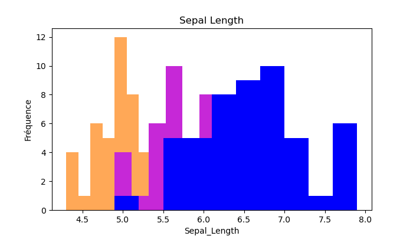

```python
plt.figure(figsize = (7, 4))
x = data["sepal_length"]


data1=x.loc[data['species']=='setosa']
data2=x.loc[data['species']=='versicolor']
data3=x.loc[data['species']=='virginica']

#plt.hist(x, bins = 20, color = "green")
plt.title("Sepal Length")
plt.xlabel("Sepal_Length")
plt.ylabel("Fréquence")

plt.hist(data1, color='#FFA857', label="setosa")
plt.hist(data2, color='#C628D7', label="versicolor")
plt.hist(data3, color = "#0000FC", label="virginica")
```

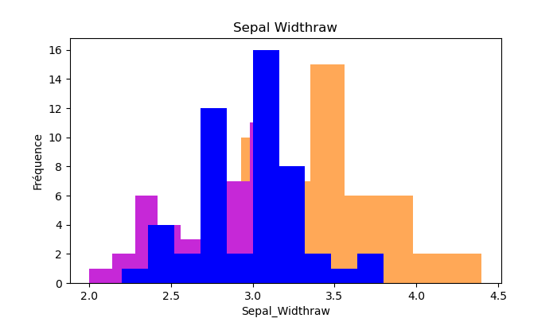

```python
plt.figure(figsize = (7, 4))
x = data["sepal_width"]


data1=x.loc[data['species']=='setosa']
data2=x.loc[data['species']=='versicolor']
data3=x.loc[data['species']=='virginica']

#plt.hist(x, bins = 20, color = "blue")
plt.title("Sepal Widthraw")
plt.xlabel("Sepal_Widthraw")
plt.ylabel("Fréquence")
plt.hist(data1, color='#FFA857', label="setosa")
plt.hist(data2, color='#C628D7', label="versicolor")
plt.hist(data3, color = "#0000FC", label="virginica")
```

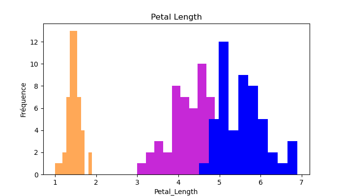

```python
plt.figure(figsize = (7, 4))
x = data["petal_length"]

data1=x.loc[data['species']=='setosa']
data2=x.loc[data['species']=='versicolor']
data3=x.loc[data['species']=='virginica']

#plt.hist(x, bins = 20, color = "yellow")
plt.title("Petal Length")
plt.xlabel("Petal_Length")
plt.ylabel("Fréquence")
plt.hist(data1, color='#FFA857', label="setosa")
plt.hist(data2, color='#C628D7', label="versicolor")
plt.hist(data3, color = "#0000FC", label="virginica")
```

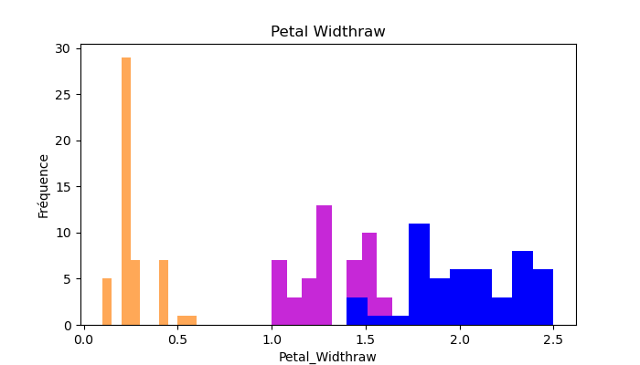

```python
plt.figure(figsize = (7, 4))
x = data["petal_width"]

data1=x.loc[data['species']=='setosa']
data2=x.loc[data['species']=='versicolor']
data3=x.loc[data['species']=='virginica']

#plt.hist(x, bins = 20, color = "red")
plt.title("Petal Widthraw")
plt.xlabel("Petal_Widthraw")
plt.ylabel("Fréquence")
plt.hist(data1, color='#FFA857', label="setosa")
plt.hist(data2, color='#C628D7', label="versicolor")
plt.hist(data3, color = "#0000FC", label="virginica")
```

2.b : Maintenant, si les classes sont représentées par deux variables, on pourrait encore utiliser l’approche par l’histogramme. Une méthode plus simple serait de tout simplement afficher les nuages de points pour chaque classe (scatter plot en anglais).

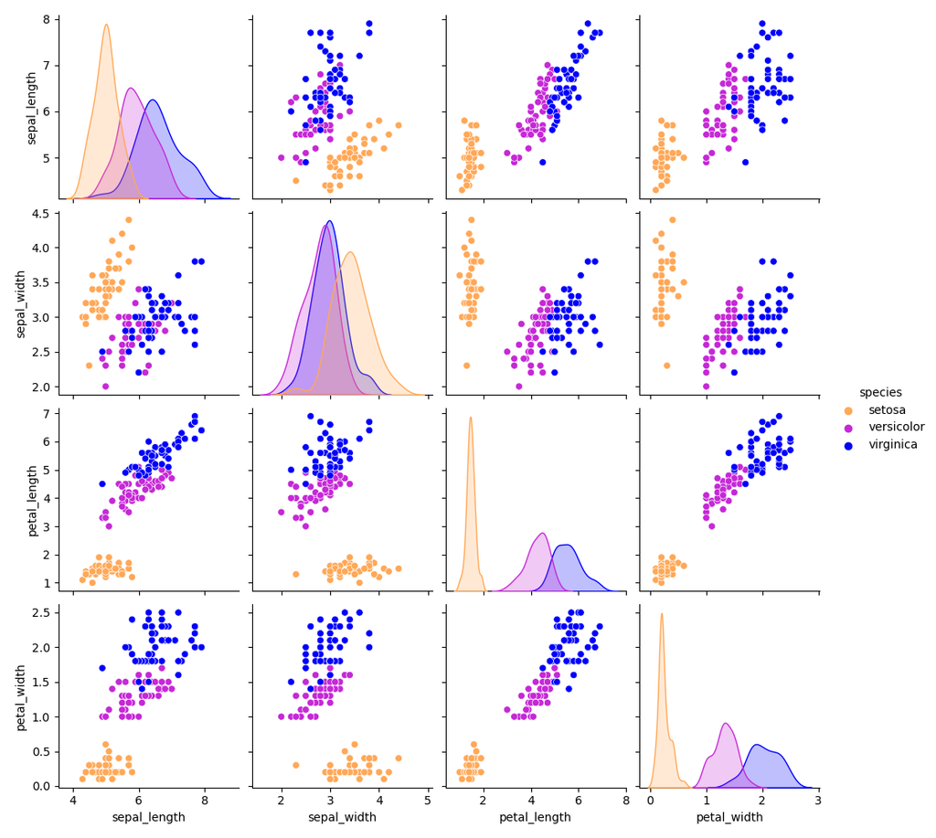

```python
sns.pairplot(data, hue="species", palette="gnuplot2_r")
```

```python
data.corr()
```

|  | sepal_length | sepal_width | petal_length | petal_width |
| --- | --- | --- | --- | --- |
| sepal_length | 1.000000 | -0.117570 | 0.871754 | 0.817941 |
| sepal_width | -0.117570 | 1.000000 | -0.428440 | -0.366126 |
| petal_length | 0.871754 | -0.428440 | 1.000000 | 0.962865 |
| petal_width | 0.817941 | -0.366126 | 0.962865 | 1.000000 |

Transfomation avec ACP

La question clé est de choisir quelles variables à utiliser.

La technique pour la transformation des variables doit être celle basée sur l’analyse des composantes principales (ACP).

```python
pca3 = PCA(n_components=3)
pca3.fit(X)
X_pca3 = pca3.transform(X)

data_pca3 = pd.DataFrame(data=X_pca3 , columns = ['PCA1', 'PCA2','PCA3'])
data_pca3['species'] = y
```

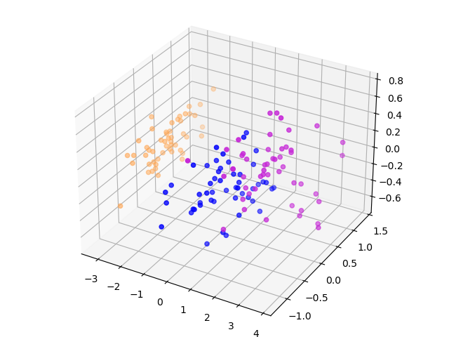

```python
xpca = data_pca3['PCA1']
ypca = data_pca3['PCA2']
zpca = data_pca3['PCA3']

colors=['#FFA857','#C628D7', "#0000FC"]

assign=[]
for species in y:
    if(species=='setosa'):
        assign.append(colors[0])
    else:
        if(species=='virginica'):
            assign.append(colors[1])
        else:
            assign.append(colors[2])


fig = plt.figure()
ax = Axes3D(fig)
ax.scatter(xpca, ypca, zpca, c=assign)
```

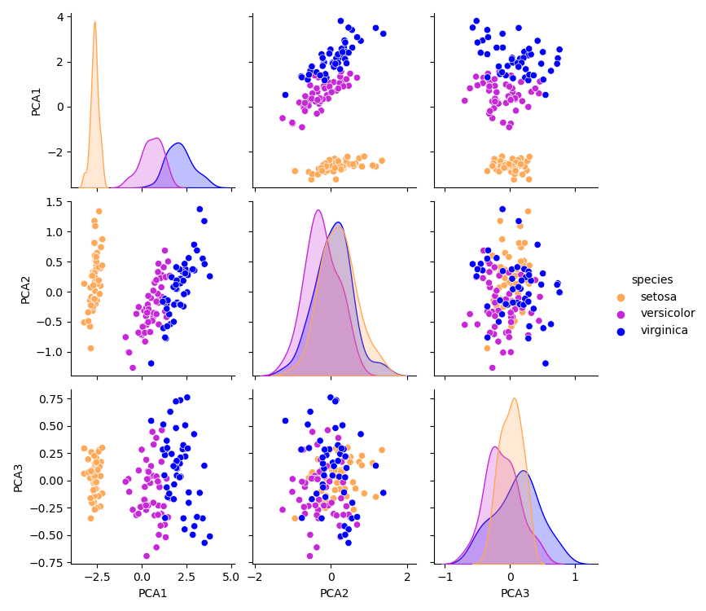

```python
sns.pairplot(data_pca3, hue='species', palette="gnuplot2_r")
```

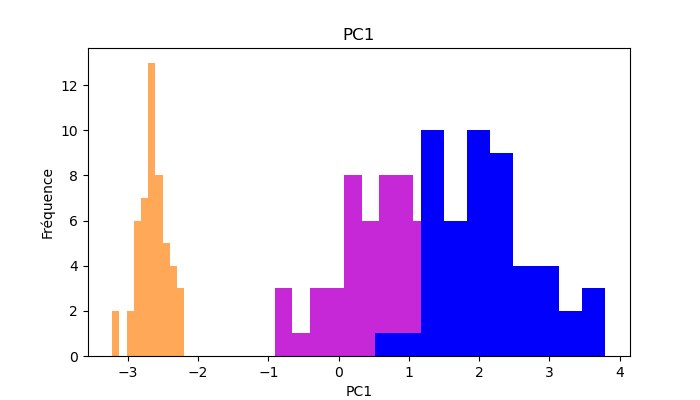

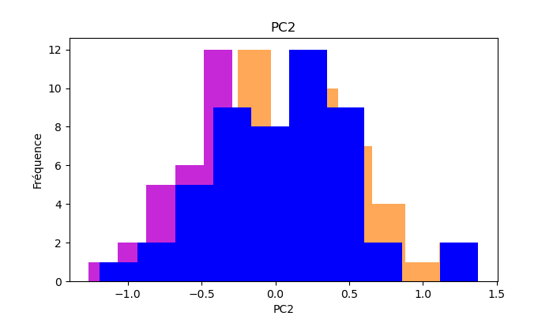

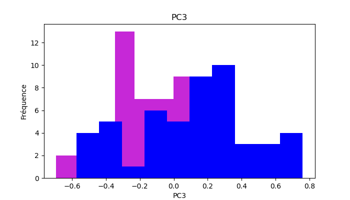

```python
x1 = data_pca3['PCA1']
x2 = data_pca3['PCA2']
x3 = data_pca3['PCA3']

data1=x1.loc[data_pca3['species']=='setosa']
data2=x1.loc[data_pca3['species']=='versicolor']
data3=x1.loc[data_pca3['species']=='virginica']

plt.figure(figsize = (7, 4))
#plt.hist(x1, bins = 20, color = "green")
plt.title("PC1")
plt.xlabel("PC1")
plt.ylabel("Fréquence")
plt.hist(data1, color='#FFA857', label="setosa")
plt.hist(data2, color='#C628D7', label="versicolor")
plt.hist(data3, color = "#0000FC", label="virginica")

data1=x2.loc[data_pca3['species']=='setosa']
data2=x2.loc[data_pca3['species']=='versicolor']
data3=x2.loc[data_pca3['species']=='virginica']

plt.figure(figsize = (7, 4))
plt.title("PC2")
plt.xlabel("PC2")
plt.ylabel("Fréquence")
plt.hist(data1, color='#FFA857', label="setosa")
plt.hist(data2, color='#C628D7', label="versicolor")
plt.hist(data3, color = "#0000FC", label="virginica")

data1=x3.loc[data_pca3['species']=='setosa']
data2=x3.loc[data_pca3['species']=='versicolor']
data3=x3.loc[data_pca3['species']=='virginica']

plt.figure(figsize = (7, 4))
plt.title("PC3")
plt.xlabel("PC3")
plt.ylabel("Fréquence")
plt.hist(data1, color='#FFA857', label="setosa")
plt.hist(data2, color='#C628D7', label="versicolor")
plt.hist(data3, color = "#0000FC", label="virginica")
```

```python
X.drop(["sepal_width"], axis = 1, inplace = True)
X.drop(["sepal_length"], axis = 1, inplace = True)
```

```python
scaler = StandardScaler()
scaler.fit(X)
X_scaled = scaler.transform(X)

pca2 = PCA(n_components=2)
pca2.fit(X_scaled)
X_pca2 = pca2.transform(X_scaled)

data_pca2 = pd.DataFrame(data=X_pca2 , columns = ['PCA1', 'PCA2'])
data_pca2['species'] = y
```

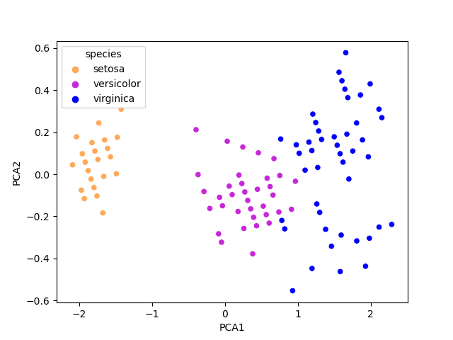

```python
fig= plt.subplots()
sns.scatterplot(x="PCA1", y="PCA2",data=data_pca2, hue="species", palette="gnuplot2_r")
```

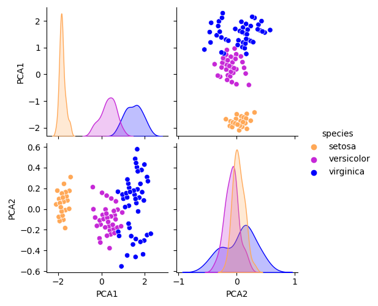

```python
sns.pairplot(data_pca2, hue='species', palette="gnuplot2_r")
```

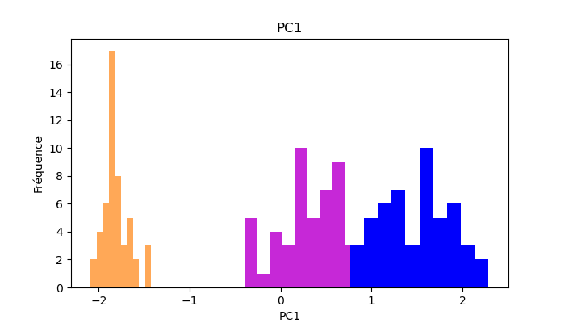

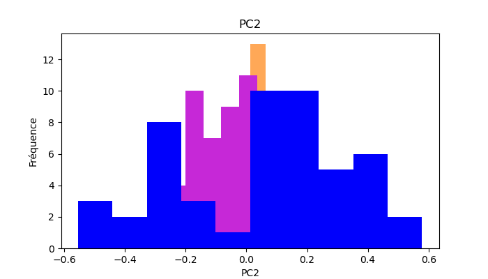

```python
x1 = data_pca2['PCA1']
x2 = data_pca2['PCA2']

data1=x1.loc[data_pca3['species']=='setosa']
data2=x1.loc[data_pca3['species']=='versicolor']
data3=x1.loc[data_pca3['species']=='virginica']
plt.figure(figsize = (7, 4))
plt.title("PC1")
plt.xlabel("PC1")
plt.ylabel("Fréquence")
plt.hist(data1, color='#FFA857', label="setosa")
plt.hist(data2, color='#C628D7', label="versicolor")
plt.hist(data3, color = "#0000FC", label="virginica")

data1=x2.loc[data_pca3['species']=='setosa']
data2=x2.loc[data_pca3['species']=='versicolor']
data3=x2.loc[data_pca3['species']=='virginica']
plt.figure(figsize = (7, 4))
plt.title("PC2")
plt.xlabel("PC2")
plt.ylabel("Fréquence")
plt.hist(data1, color='#FFA857', label="setosa")
plt.hist(data2, color='#C628D7', label="versicolor")
plt.hist(data3, color = "#0000FC", label="virginica")
```